# Final take-home exam

39

Due: Wednesday, February 10 by 08:00 pm CET

# Instructions

- Create an Rmd-file with your group number (equivalent to StudIP group) in the ‘author’ heading and answer the following questions.
- When all answers are ready, ‘Knit’ the document to produce a HTML file.
- Create a ZIP archive called “IDA-final-Group-XYZ.zip” (where ‘XYZ’ is *your* group number) containing:
  - an R Markdown file “IDA-final-Group-XYZ.Rmd”
  - a knitted HTML document “IDA-final-Group-XYZ.html”
  - any other files necessary to compile your Rmarkdown to HTML (data, pictures etc.)
- Upload the ZIP archive on Stud.IP in your group folder before the deadline (see above). You may upload as many times as you like before the deadline, only your final submission will count.
- If you run `brms::brm` in an R code chunk, make sure to include `results='hide'` as an option to that code chunk to suppress the output of Stan.
- If you have questions, pose them on StudIP in the new section for questions on the exam. Obviously, do **not** post solutions.

# Exercise 1: Identify hypotheses & relevant measures [8 points]

Read the paper by Brashears & Minda (2020) carefully. (Authors/paper henceforth referred to as B&M.) The focus for us is on the sections “Methods” and “Results”.

## Ex 1.a Identify the research hypotheses [4 points]

B&M address three main research hypotheses, and they conduct three main statistical analyses, one for each of three relevant research hypotheses. We will refer to these research hypotheses here as “Learning Speed”, “Accuracy” and “Strategy”.

Here’s a formulation of the “Strategy” hypothesis:

> “Strategy”: The proportion of categorization choices for each subject, which are indicative of a ‘critical attribute’ categorization strategy (as stored in variable `CA` and derived from choices in the critical trials `T1` … `T10`), is larger for the “easily verbalizable” condition (level `VB` of variable `Cond`), than in the “not-easily verbalizable” condition (level `NB` of variable `Cond`).

Formulate the remaining two hypotheses in natural language as precisely as possible, using -wherever possible- reference to the names and/or values of variables in the data set supplied by B&M, following the above example. (That is, if some hypothesis relates to a dependent or independent variable, then add the information of where in the data set this variable is stored, and/or which values of it you are referring to precisely.)

**Solution**

> “Learning Speed”: The number of trials before making a correct categorization in 12 trials in a row (minimum 60 trials) (as stored in variable `Trials`) is smaller for the “easily verbalize” condition (level `VB` of variable `Cond`) than for the “not-easily verbalize” condition (level `NB` of variable `Cond`).

> “Accuracy”: The proportion of correctly classifying the training items in the test phase (as stored in variable `Accuracy` and derived from choices in the critical trials `TA1` … `TA5` and `TB1` … `TB5`) is higher for “easily verbalize” condition (level `VB` of variable `Cond`) than for the “not-easily verbalize” condition (level `NB` of variable `Cond`).

## Ex 1.b Previous results [3 points]

What results do B&M report for these three hypotheses? Make a short statement for each hypothesis, e.g., “find evidence for/against” or “find no evidence”, for each hypothesis. (Don’t overthink this! The question is about what the authors conclude from their analyses. No need to go down the rabbit hole here and triple-check whether you would draw similar conclusions from the reported analyses.)

**Solution**

> “Learning Speed”: Learning rate for the easily-verbalizable condition and the not-easily-verbalizable condition did not differ significantly from one another, so evidence against the hypothesis.

> “Accuracy”: Accuracy was significantly higher in easily-verbalizable condition than in the not-easily-verbalizable condition, so evidence in favor of the hypothesis.

> “Strategy”: The participants showed preference for CA strategy in the easily-verbalizable condition, while they showed no preference for either strategy in the non-easily-verbalizable condition, so evidence in favor of the hypothesis.

## Ex 1.c Kind of experiment [1 point]

What kind of experiment is this? I.e., which independent (explanatory) variables are there? Are they metric or categorical factors? If factors, how many levels (ordered, unordered?) do they have? Any within- or between-subjects manipulations?

**Solution** In this experiment, the influence of verbalizability of features (independent variable) on learning speed, accuracy, and learning strategy (dependent variables) is tested. Specifically, the independent variable, verbalizability of features, is divided into easily-verbalizable features and not-easily-verbalizable features and provided as a stimulus. Therefore, it is a categorical factor, and unordered. The verbalizability of features of stimuli is a between-subject independent variable.

# Exercise 2: Inspect the data [12 points]

We load the data:

```r
d <- read_csv('BM_data.csv')
```

## Ex 2.a Get some counts [2 points]

Use R to retrieve:

- the number of participants contained in the data set
- the number of times each condition (NV and VB) occurs in the data

**Solution**

```r
num_participants <- d %>%
  group_by(Subj) %>%
  nrow

num_condition <- d %>%
  group_by(Cond) %>%
  count()

(num_NV <- num_condition[1,2])
```

```
## # A tibble: 1 x 1
##       n
##   <int>
## 1    34
```

```r
(num_VB <- num_condition[2,2])
```

```
## # A tibble: 1 x 1
##       n
##   <int>
## 1    34
```

## Ex 2.b Tidy up Part 1 [2 points]

In some of our subsequent analyses, we will be interested in the categorization decision of each subject for each critical experimental trial. For this purpose, the data in `d` is not tidy. Use common `dplyr` functions to create a new variable `d_tidy` which contains the same data as `d` (except for data from T11-T20) in a tidy format. So, `d_tidy` will include one row for each individual categorization trial of each subject. Since we will not be analyzing the “single-feature trials” (T11-T20), exclude these. Name the two new columns you will create by pivoting `trial_label` and `response`. Include the first 10 lines of your `d_tidy` to the HTML output.

**Solution**

```r
d_tidy <- d %>%
  select(., -seq(26,35)) %>%
  pivot_longer(., cols = seq(6,25), names_to = "trial_label", values_to = "response")
d_tidy
```

```
## # A tibble: 1,360 x 9
##     Subj Cond   Feat Trials Accuracy    CA    FR trial_label response
##    <dbl> <chr> <dbl>  <dbl>    <dbl> <dbl> <dbl> <chr>       <chr>
##  1     2 VB        5     60        1   0.9   0.1 TA1         A
##  2     2 VB        5     60        1   0.9   0.1 TA2         A
##  3     2 VB        5     60        1   0.9   0.1 TA3         A
##  4     2 VB        5     60        1   0.9   0.1 TA4         A
##  5     2 VB        5     60        1   0.9   0.1 TA5         A
##  6     2 VB        5     60        1   0.9   0.1 TB1         B
##  7     2 VB        5     60        1   0.9   0.1 TB2         B
##  8     2 VB        5     60        1   0.9   0.1 TB3         B
##  9     2 VB        5     60        1   0.9   0.1 TB4         B
## 10     2 VB        5     60        1   0.9   0.1 TB5         B
## # … with 1,350 more rows
```

## Ex 2.c Tidy up Part 2 [2 points]

The tibble in `d_tidy` now contains a data column with entries like `TA1` or `T10`, but actually `TA1` and `T10` are quite different types of trials. So, let’s clean up and structure some more. Introduce a new column called `trial_type`, which contains the information whether each row’s trial is from one of the four categories: `category_A`, `category_B`, `exception_1`, or `exception_2`. The trials of types `exception_1` and `exception_2` differ with respect to the expected response under the “characteristic attribute” (CA) strategy. Trials of type `exception_1` expect response “B” under CA. Add also a column called `expected_repsonse` containing the expected responses for each trial type (assuming strategy CA, where that is relevant).

**Solution**

```r
d_tidy <- d_tidy %>% group_by(trial_label) %>% mutate(trial_type = case_when(
str_detect(trial_label, "A") ~ "category_A",
str_detect(trial_label, "B") ~ "category_B",
# needs to come before "T[1-5]"
str_detect(trial_label, "T10") ~ "exception_2",
str_detect(trial_label, "T[1-5]") ~ "exception_1",
str_detect(trial_label, "T[6-9]") ~ "exception_2",
TRUE ~ "error"
))

d_tidy <- d_tidy %>% group_by(trial_label) %>% mutate(expected_response = case_when(
str_detect(trial_label, "A") ~ "A",
str_detect(trial_label, "B") ~ "B",
# needs to come before "T[1-5]"
str_detect(trial_label, "T10") ~ "A",
str_detect(trial_label, "T[1-5]") ~ "B",
str_detect(trial_label, "T[6-9]") ~ "A",
TRUE ~ "error"
))

d_tidy
```

```
## # A tibble: 1,360 x 11
## # Groups:   trial_label [20]
##     Subj Cond   Feat Trials Accuracy    CA    FR trial_label response trial_type
##    <dbl> <chr> <dbl>  <dbl>    <dbl> <dbl> <dbl> <chr>       <chr>    <chr>
##  1     2 VB        5     60        1   0.9   0.1 TA1         A        category_A
##  2     2 VB        5     60        1   0.9   0.1 TA2         A        category_A
##  3     2 VB        5     60        1   0.9   0.1 TA3         A        category_A
##  4     2 VB        5     60        1   0.9   0.1 TA4         A        category_A
##  5     2 VB        5     60        1   0.9   0.1 TA5         A        category_A
##  6     2 VB        5     60        1   0.9   0.1 TB1         B        category_B
##  7     2 VB        5     60        1   0.9   0.1 TB2         B        category_B
##  8     2 VB        5     60        1   0.9   0.1 TB3         B        category_B
##  9     2 VB        5     60        1   0.9   0.1 TB4         B        category_B
## 10     2 VB        5     60        1   0.9   0.1 TB5         B        category_B
## # … with 1,350 more rows, and 1 more variable: expected_response <chr>
```

## Ex 2.d Double-check relevant summary stats by B&M [3 points]

Checking other researchers’ results is not imprudent, but part of a healthy self-correcting and cooperative scientific community. Therefore, add to the tibble in `d` columns `CA_check` and `Accuracy_check`, calculating these values yourself from the information stored in columns `trial_type` and `expected_response` of `d_tidy`. (NB: you may want to use some form of ‘joining’ tibbles, or you just produce two single vectors `CA_check` and `Accuracy_check`.) Finally, use R (e.g., functions like `all` or `any`) to check if your calculations agree the information provided in columns `CA` and `Accuracy` of `d`.

```r
d_ca_check <- d_tidy %>%
  filter(!str_detect(trial_label, "[AB]")) %>%
  group_by(Subj) %>%
  mutate(CA_check = mean(as.character(response) == as.character(expected_response))) %>%
  select(Subj, CA_check) %>%
  unique

d_accuracy_check <- d_tidy %>%
    filter(str_detect(trial_label, "[AB]")) %>%
  group_by(Subj) %>%
  mutate(Accuracy_check = mean(as.character(response) == as.character(expected_response))) %>%
  select(Subj, Accuracy_check) %>%
  unique

d_ca_check
```

```
## # A tibble: 68 x 2
## # Groups:   Subj [68]
##     Subj CA_check
##    <dbl>    <dbl>
##  1     2      0.9
##  2     4      0.5
##  3     6      1
##  4     8      0.9
##  5    10      0.6
##  6    12      0.2
##  7    14      0.7
##  8    16      1
##  9    18      1
## 10    20      0.1
## # … with 58 more rows
```

```r
d_accuracy_check
```

```
## # A tibble: 68 x 2
## # Groups:   Subj [68]
##     Subj Accuracy_check
##    <dbl>          <dbl>
##  1     2            1
##  2     4            0.5
##  3     6            1
##  4     8            0.6
##  5    10            0.3
##  6    12            0.8
##  7    14            0.6
##  8    16            1
##  9    18            1
## 10    20            0.8
## # … with 58 more rows
```

```r
d <- d %>%
  full_join(d_ca_check) %>%
  full_join(d_accuracy_check)

all(d["CA_check"] == d["CA"])
```

```
## [1] TRUE
```

```r
all(d["Accuracy_check"] == d["Accuracy"])
```

```
## [1] TRUE
```

## Ex 2.e Summary statistics [3 points]

Use common `dplyr` functions, as well as the function `aida::bootstrapped_CI` to produce a tibble with the exact form as shown below (including ordering of rows and columns, as well as column names!) showing the mean, the lower- and the upper-bound of the 95% bootstrapped confidence interval of the mean (as returned by `aida::bootstrapped_CI`) of the three relevant measures of interest.

```
## # A tibble: 6 x 5
##   measure  Cond  lower mean  upper
##   <chr>    <chr> <chr> <chr> <chr>
## 1 Trials   NV    ...   ...   ...
## 2 Trials   VB    ...   ...   ...
## 3 Accuracy NV    ...   ...   ...
## 4 Accuracy VB    ...   ...   ...
## 5 CA       NV    ...   ...   ...
## 6 CA       VB    ...   ...   ...
```

**Solution**

```r
d_VB <- d_tidy %>%
  filter(Cond == "VB") %>%
  group_by(Subj) %>%
  summarise(Trials = mean(Trials), Accuracy = mean(Accuracy), CA = mean(CA))

d_NV <- d_tidy %>%
  filter(Cond == "NV") %>%
  group_by(Subj) %>%
  summarise(Trials = mean(Trials), Accuracy = mean(Accuracy), CA = mean(CA))

VB_acc <- aida::bootstrapped_CI(d_VB$Accuracy)
VB_trials <- aida::bootstrapped_CI(d_VB$Trials)
VB_ca <- aida::bootstrapped_CI(d_VB$CA)
NV_acc <- aida::bootstrapped_CI(d_NV$Accuracy)
NV_trials <- aida::bootstrapped_CI(d_NV$Trials)
NV_ca <- aida::bootstrapped_CI(d_NV$CA)

measure <- c("Trials", "Trials", "Accuracy", "Accuracy", "CA", "CA")
cond <- c("NV", "VB","NV", "VB","NV", "VB")

summary_stats <- full_join(NV_trials, VB_trials) %>%
  full_join(., NV_acc) %>%
  full_join(., VB_acc) %>%
  full_join(., NV_ca) %>%
  full_join(., VB_ca) %>%
  mutate(measure = measure, Cond = cond) %>%
  select(measure, Cond, lower, mean, upper)

summary_stats
```

```
## # A tibble: 6 x 5
##   measure  Cond   lower   mean   upper
##   <chr>    <chr>  <dbl>  <dbl>   <dbl>
## 1 Trials   NV    76.4   89.5   104.
## 2 Trials   VB    68.5   82.7   101.
## 3 Accuracy NV     0.738  0.8     0.856
## 4 Accuracy VB     0.888  0.929   0.965
## 5 CA       NV     0.409  0.521   0.632
## 6 CA       VB     0.718  0.821   0.903
```

# Exercise 3: Vizualization [7 points]

We will look at plots, one for each of the three main research hypotheses. For your own understanding, think about whether you can “see evidence” in favor of or against each hypothesis. (You do not have to comment on this in your submission.)

## Ex 3.a Vizualize the “Learning Speed” data [3 points]

Visualize the data relevant for addressing the “Learning Speed” hypothesis. Use a histogram with the most fine-grained binning which is reasonable given the nature of the data (i.e., manipulate argument `binwidth` in function `geom_histogram`). Use two facets, one for each relevant level of the categorical predictor.

**Solution**

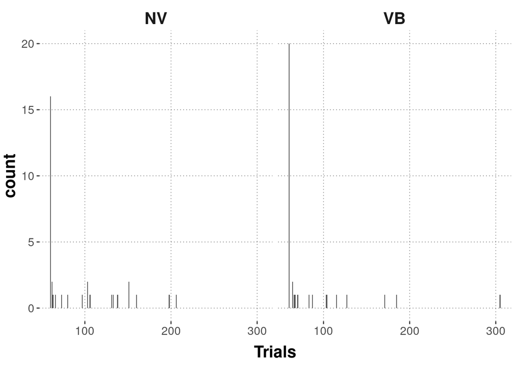

```r
d_unique <- d_tidy %>%
  group_by(Subj) %>%
  distinct(Subj, .keep_all = TRUE) %>%
   select(Subj, Cond, Trials, Accuracy, CA)

d_unique %>%
  ggplot(aes(x = Trials)) +
  # Some values still look glued together, but we think that this is a
  # good trade off point for having bins as thick as possible while still
  # preventing values from being glued together in the histogram.
  geom_histogram(binwidth=1) +
  facet_wrap(Cond ~ .)
```

## Ex 3.b Vizualize the “Accuracy” data [2 points]

Make a histogram plot, using facets, for the data relevant to the “Accuracy” hypothesis.

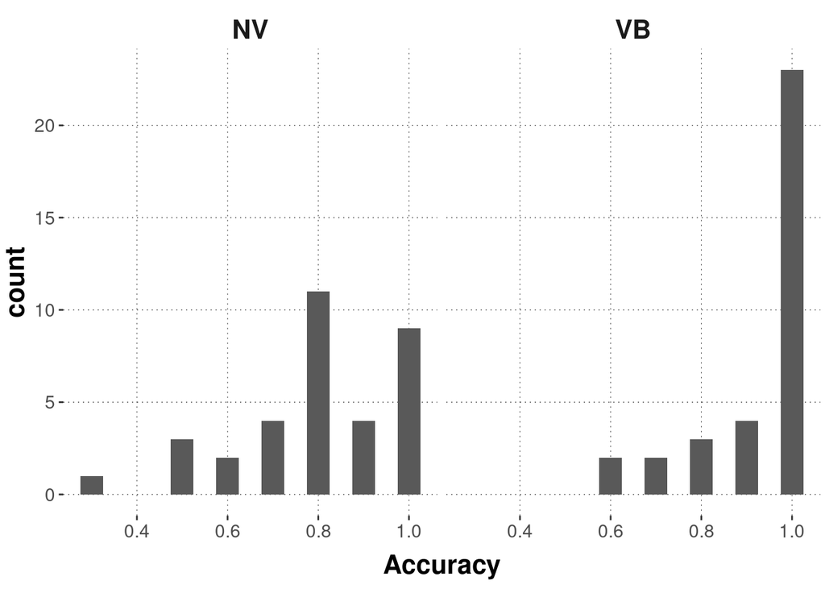

```r
d_unique %>%
  ggplot(aes(x = Accuracy)) +
  geom_histogram(binwidth=0.05) +
  facet_wrap(Cond ~ .)
```

## Ex 3.c Vizualize the “Strategy” data [2 points]

Plot the data for the “Strategy” hypothesis. You can use a histogram and facets here as well.

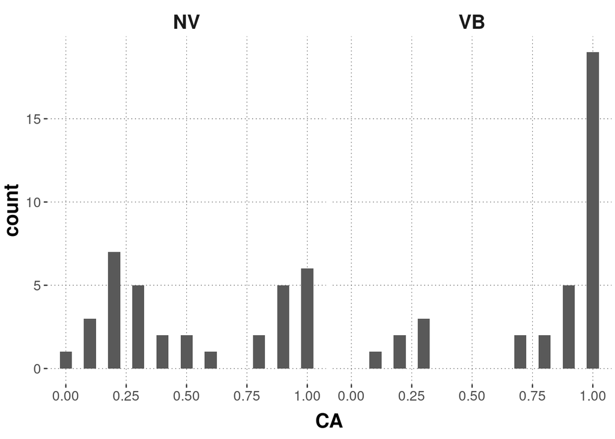

```r
d_unique %>%
  ggplot(aes(x = CA)) +
  geom_histogram(binwidth=0.05) +
  facet_wrap(Cond ~ .)
```

# Exercise 4: Hypothesis testing [22 points]

## Ex 4.a Testing the “Learning Speed” hypothesis [6 points]

Test the “Learning Speed” hypothesis using a Bayesian linear regression model, following the assumption made in the paper that the measures in `Trials` are normally distributed. Make sure to also record samples from the prior (even if we don’t need them), and set the relevant prior for the slope term to a Student’s $t$ distribution with 1 degree of freedom, mean 0 and standard deviation 100. Test the hypothesis with `brms::hypothesis` and interpret the outcome with explicit mentioning of the quantities you base your interpretation on.

```r
d_unique <- d_unique %>%
  mutate(
    Cond = factor(Cond)
  )

fit_ls <- brm(
  formula = Trials ~ Cond,
  data = d_unique,
  prior = prior(student_t(1, 0, 100),  class = 'b'),
  sample_prior = 'yes',
  iter = 20000
)
```

```r
(summary(fit_ls))
```

[output not shown]

```r
# mu_NV > mu_VB is our hypothesis
brms::hypothesis(fit_ls, "CondNV > 0")
```

```
## Hypothesis Tests for class b:
##     Hypothesis Estimate Est.Error CI.Lower CI.Upper Evid.Ratio Post.Prob Star
## 1 (CondNV) > 0     6.66     11.46   -12.37    25.49        2.6      0.72
## ---
## 'CI': 90%-CI for one-sided and 95%-CI for two-sided hypotheses.
## '*': For one-sided hypotheses, the posterior probability exceeds 95%;
## for two-sided hypotheses, the value tested against lies outside the 95%-CI.
## Posterior probabilities of point hypotheses assume equal prior probabilities.
```

** Analysis ** With an evidence ratio of around 2.5, we have evidence that is hardly worth ink or breath in favor of our hypothesis that learning speed is higher for the easily verbalized condition than for the non-easily verbalized condition (stated in 1.a). Also, the credible interval’s lower bound is below the critical value of 0, as is the upper bound above 0. As such, the model and data provide no substantial evidence in favor of or against this hypothesis, so we withhold judgement.

## Ex 4.b Testing the “Accuracy” hypothesis [8 points]

B&M test the “Accuracy” hypothesis based on the assumption that the measures in `Accuracy` are normally distributed. If you can, explain in one concise sentence why this normality assumption might be criticized in the case at hand. If you cannot think of a different analysis you like better, follow this strategy to test the “Accuracy” hypothesis with a Bayesian regression model following the same general approach as in the previous exercise. If you can think of an analysis you might prefer, do that (for 2 extra points). Use the same priors as in the previous exercise.

**Solution**

We think that a normal distribution is inappropriate here, since the accuracy is plausibly generated by a binomial distribution, which in turn comes from an underlying Bernoulli distribution (see column `correct` in code below).

```r
d_acc <- d_tidy %>%
  filter(str_detect(trial_label, "[AB]")) %>%
  group_by(Subj) %>%
  mutate(correct = response == expected_response) %>%
  mutate(Cond = factor(Cond))


fit_acc <- brm(
  formula = correct ~ Cond,
  data = d_acc,
  family = bernoulli(link = "logit"),
  prior = prior(student_t(1, 0, 100), class='b'),
  sample_prior = 'yes',
  iter = 20000
)
```

```r
summary(fit_acc)
```

```
##  Family: bernoulli
##   Links: mu = logit
## Formula: correct ~ Cond
##    Data: d_acc (Number of observations: 680)
## Samples: 4 chains, each with iter = 20000; warmup = 10000; thin = 1;
##          total post-warmup samples = 40000
##
## Population-Level Effects:
##           Estimate Est.Error l-95% CI u-95% CI Rhat Bulk_ESS Tail_ESS
## Intercept     2.59      0.21     2.19     3.02 1.00    20262    20786
## CondNV       -1.20      0.25    -1.71    -0.72 1.00    23843    23071
##
## Samples were drawn using sampling(NUTS). For each parameter, Bulk_ESS
## and Tail_ESS are effective sample size measures, and Rhat is the potential
## scale reduction factor on split chains (at convergence, Rhat = 1).
```

```r
# mu_NV < mu_VB is our hypothesis
brms::hypothesis(fit_acc, "CondNV < 0")
```

```
## Hypothesis Tests for class b:
##     Hypothesis Estimate Est.Error CI.Lower CI.Upper Evid.Ratio Post.Prob Star
## 1 (CondNV) < 0     -1.2      0.25    -1.62     -0.8        Inf         1    *
## ---
## 'CI': 90%-CI for one-sided and 95%-CI for two-sided hypotheses.
## '*': For one-sided hypotheses, the posterior probability exceeds 95%;
## for two-sided hypotheses, the value tested against lies outside the 95%-CI.
## Posterior probabilities of point hypotheses assume equal prior probabilities.
```

With an evidence ratio of Inf and a post. probability 1, we have decisive evidence in favor of our hypothesis that the accuracy is higher for the easily verbalized condition than for the not-easily verbalized condition. As such, we accept our hypothesis.

## Ex 4.c Testing the “Strategy” hypothesis [8 points]

Test the “Strategy” hypothesis in the way that you think is best appropriate (but using a method that we have covered in class).

**Solution** Like in 4.b, we think that a normal distribution is inappropriate here, since `CA` is plausibly generated by a binomial distribution, which in turn comes from an underlying Bernoulli distribution (see column `is_ca` in code below).

```r
d_ca <- d_tidy %>%
  filter(!str_detect(trial_label, "[AB]")) %>%
  group_by(Subj) %>%
  mutate(is_ca = response == expected_response) %>%
  mutate(Cond = factor(Cond))


fit_ca <- brm(
  formula = is_ca ~ Cond,
  data = d_ca,
  family = bernoulli(link = "logit"),
  prior = prior(student_t(1, 0, 100), class='b'),
  sample_prior = 'yes',
  iter = 20000
)
```

```r
summary(fit_ca)
```

```
##  Family: bernoulli
##   Links: mu = logit
## Formula: is_ca ~ Cond
##    Data: d_ca (Number of observations: 680)
## Samples: 4 chains, each with iter = 20000; warmup = 10000; thin = 1;
##          total post-warmup samples = 40000
##
## Population-Level Effects:
##           Estimate Est.Error l-95% CI u-95% CI Rhat Bulk_ESS Tail_ESS
## Intercept     1.53      0.14     1.25     1.81 1.00    23249    22791
## CondNV       -1.44      0.18    -1.80    -1.10 1.00    27637    25698
##
## Samples were drawn using sampling(NUTS). For each parameter, Bulk_ESS
## and Tail_ESS are effective sample size measures, and Rhat is the potential
## scale reduction factor on split chains (at convergence, Rhat = 1).
```

```r
# mu_NV < mu_VB is our hypothesis
brms::hypothesis(fit_ca, "CondNV < 0")
```

```
## Hypothesis Tests for class b:
##     Hypothesis Estimate Est.Error CI.Lower CI.Upper Evid.Ratio Post.Prob Star
## 1 (CondNV) < 0    -1.44      0.18    -1.74    -1.15        Inf         1    *
## ---
## 'CI': 90%-CI for one-sided and 95%-CI for two-sided hypotheses.
## '*': For one-sided hypotheses, the posterior probability exceeds 95%;
## for two-sided hypotheses, the value tested against lies outside the 95%-CI.
## Posterior probabilities of point hypotheses assume equal prior probabilities.
```

With an evidence ratio of Inf and a post. probability 1, we have decisive evidence in favor of our hypothesis that the proportion of categorization choices for each subject, which are indicative of a ‘critical attribute’ categorization strategy, than in the “not-easily verbalizable” condition. As such, we accept our hypothesis.

# Exercise 5 (challenge question): Comparison to ANOVA analysis [5 points]

B&M’s ANOVA-based analysis for the “Strategy” Hypothesis actually also tested a fourth hypothesis, for which a significant test result was obtained. Describe in words what that finding was. Use conjugacy (starting from flat priors) to quickly sample from a Bayesian posterior to test this additional hypothesis using Kruschke’s ternary logic for hypothesis testing. (**Hint:** Did you really think you could take this final w/o addressing an issue translatable into a question about whether some stupid coin is fair or biased on some way or other?)

**Solution:** The reported main effect of category amounts to saying that participants seem to have favored choices indicative of a “characterizing attribute” (CA) strategy.

Because the choice of strategy is binary, we assume Beta as prior. Since we want a flat prior, we choose a = 1 and b = 1 as the parameters.
$$\begin{align*}
P(\theta) & = Beta(1,1) \\
P(\theta \mid N, k) & = \text{Beta}( 1+k, 1 + N - k)
\end{align*}$$
We then need to retrieve N and k from our data:

```r
# number of trials in which decision was based on CA strategy
k <-  d_tidy %>%
  # only look at test trials in which we can determine used strategy
  filter(!str_detect(trial_label, "[AB]")) %>%
  # count number of trials in which the response is the same as the expected response,  assuming CA strategy
  filter(., as.character(response) == as.character(expected_response)) %>%
  nrow()
k
```

```
## [1] 456
```

```r
# number of test trials
N <- d_tidy %>%
  filter(!str_detect(trial_label, "[AB]")) %>%
  nrow()
N
```

```
## [1] 680
```

Now we can compute the posterior distribution using conjugacy:

$$\begin{align*}
P(\theta \mid 680, 456)& = \text{Beta}(1+456, 1+680-456) \\
P(\theta \mid 680, 456)& = \text{Beta}( 457, 225)
\end{align*}$$

Now, we can estimate the bias parameter by sampling from the posterior distribution

```r
samples <- rbeta(1e6, 457, 225)
aida::summarize_sample_vector(samples, "bias towards CA")
```

```
## # A tibble: 1 x 4
##   Parameter       `|95%`  mean `95%|`
##   <chr>            <dbl> <dbl>  <dbl>
## 1 bias towards CA  0.634 0.670  0.705
```

The mean estimate for the bias towards use of strategy CA is higher than 0.5 and both bounds of the credible interval are bigger than 0.5, so according to Kruschke’s ternary logic, we accept the hypothesis that there is a preference for adopting the CA strategy without taking into account the influence of condition.